# Intro to Choropleth using R

[Ari Lamstein](https://twitter.com/AriLamstein) did a 5-week email course on how to map census data in R. This is my attempt to create a single page version of the entire course.

The R Package `choroplethr` is used for this exercise.

### Installation of the required libraries

```r
install.packages("choroplethr")
install.packages("choroplethrMaps")
```

The library comes with some datasets. The dataset `df_pop_state` has population by state, and the dataset `df_state_demographics` has some demographic information by state. Now, let’s load these two datasets

```r
library(choroplethr)
data(df_pop_state)
data(df_state_demographics)
```

### Our first choropleth

This is as simple as calling the `state_choropleth` function from the `choroplethr` library.

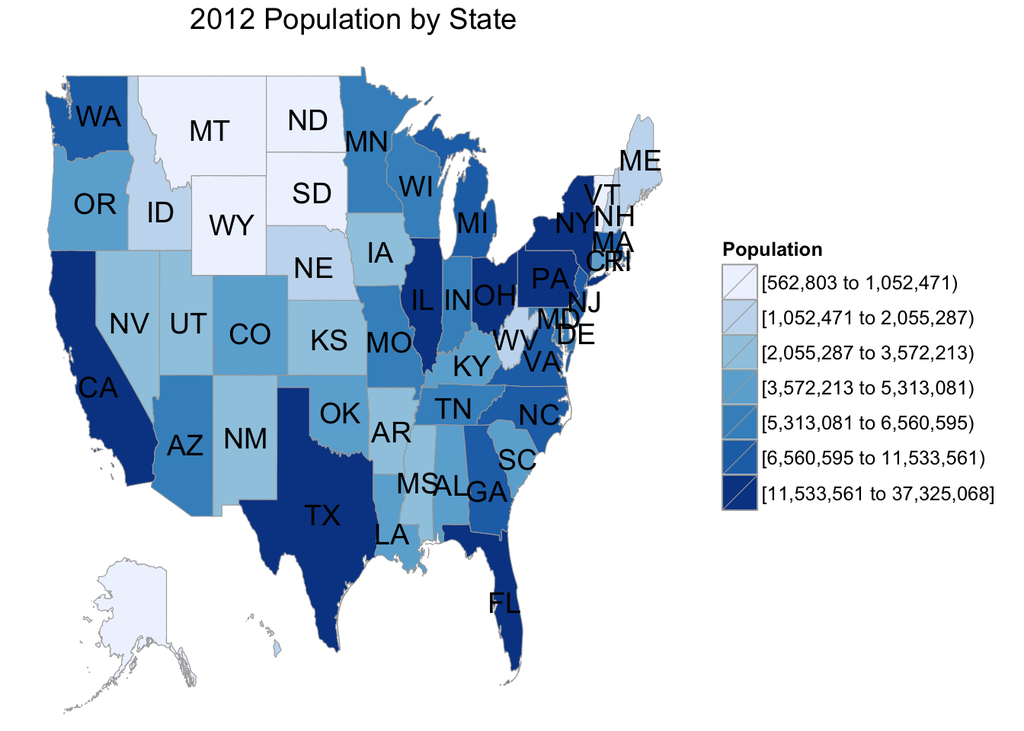

```r
state_choropleth(df_pop_state, title="2012 Population by State", legend="Population")
```

Let’s try to look at those states whose population is less than 1 million.

To do the data munging, let’s use the `dplyr` package.

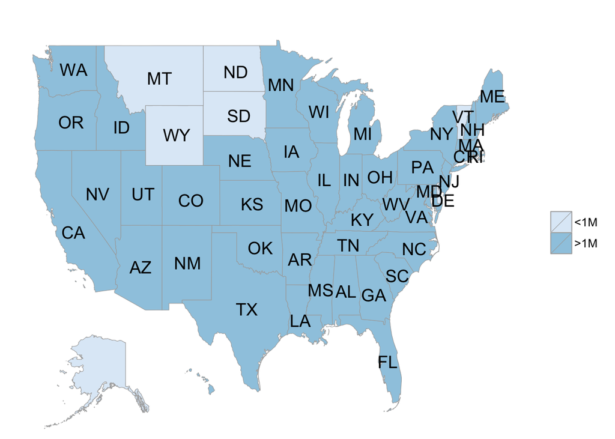

```r
library(dplyr)
#Create two dataframes- one of states with less than 1 million population
#and another of states with more than 1 million population

states_w_less_than_1m <- df_pop_state %>%
  filter(value < 1000000) %>%
  mutate(value="<1M")

states_w_more_than_1m <- df_pop_state %>%
  filter(!(region %in% states_w_less_than_1m$region)) %>%
  mutate(value=">1M")

#Merge the above two dataframes
states_pop_seg_by_million <- data.frame(rbind(states_w_more_than_1m, states_w_less_than_1m))

state_choropleth(states_pop_seg_by_million)
```

###Per-capita income by state The dataset `df_state_demographics` has *per_capita* data by state. Let’s plot that now. Note that the `state_choropleth` function requires two columns: `region` and `value`. Let’s create a new dataset with those two columns with `value` corresponding to the per-capita of the state.

```r
#Display the column names of the dataset
names(df_state_demographics)
```

```
## [1] "region"            "total_population"  "percent_white"
## [4] "percent_black"     "percent_asian"     "percent_hispanic"
## [7] "per_capita_income" "median_rent"       "median_age"
```

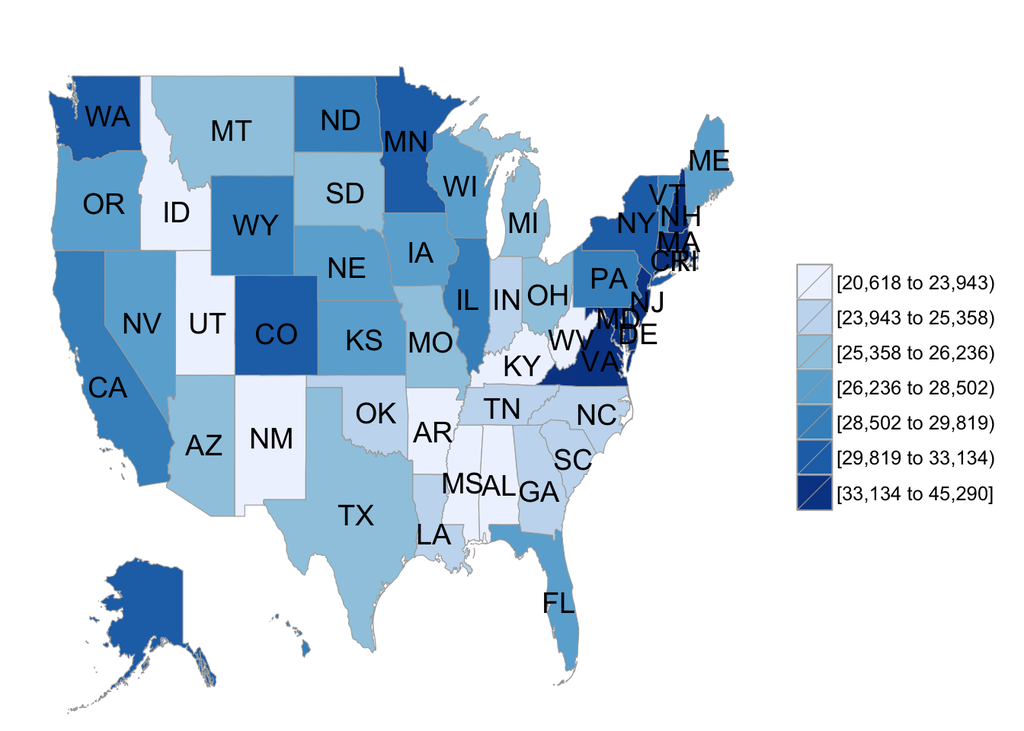

```r
#Create a dataset with state and per capita
df_state_percapita <- data.frame(region=df_state_demographics$region, value=df_state_demographics$per_capita_income)

df_state_percapita$region <- as.character(df_state_percapita$region)

#Plot it on the choropleth
state_choropleth(df_state_percapita)
```

### Questions

Take the demographic dataset and plot the following:

- States by their proportion of black to white
- States by their proportion of asian to hispanic

## Mapping the population for each county

Let’s do the exercise, now at county-level. This is available in the `df_pop_county` dataset.

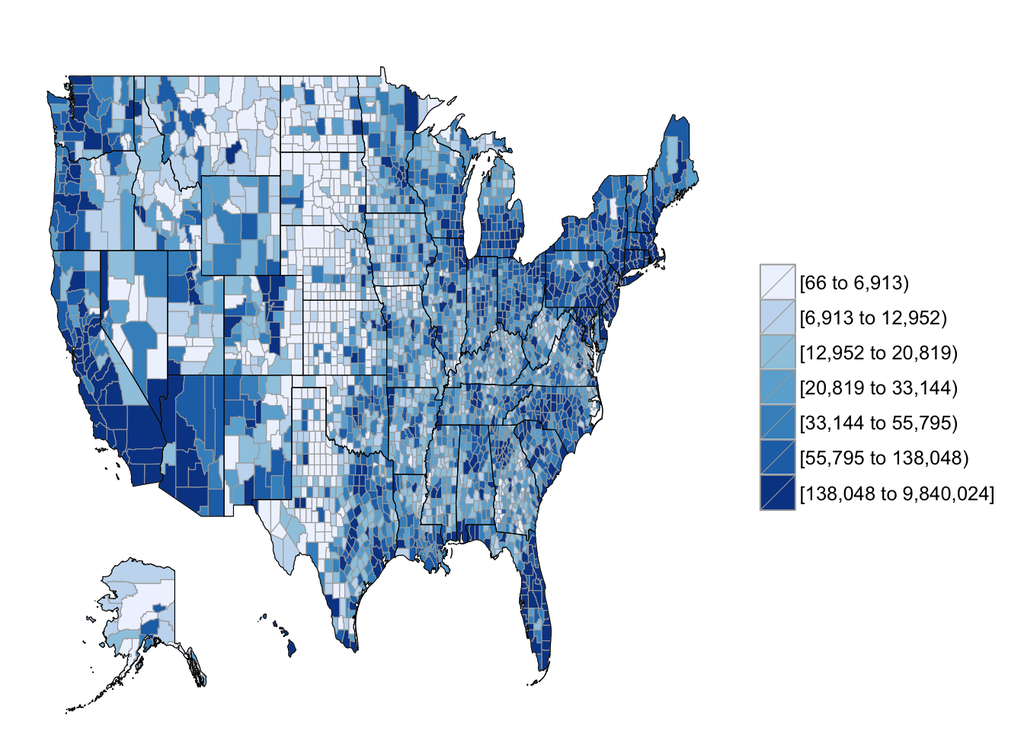

```r
data(df_pop_county)

county_choropleth(df_pop_county)
```

How about zooming on just one state and looking into it? Let’s zoom on california

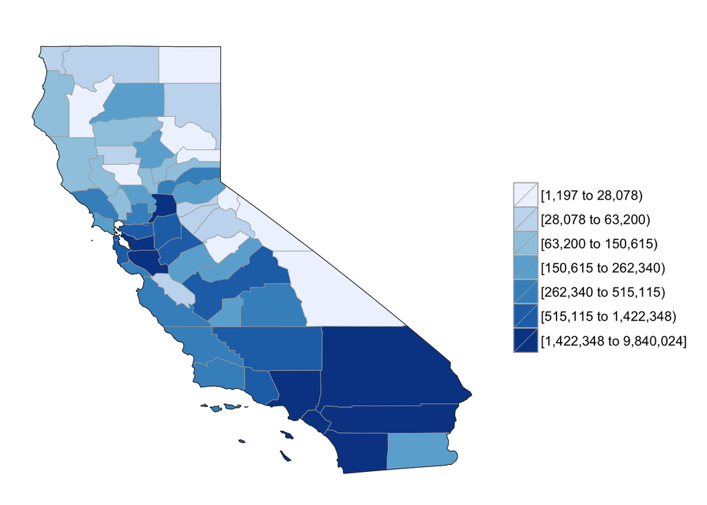

```r
county_choropleth(df_pop_county, state_zoom="california")
```

## Mapping population of Zip codes in Manhattan

For this, need to install `choroplethrZip` package. The package is huge. ~60MB. Keep that in mind.

```r
library(devtools)
#Uncomment and run the package installation, if you don't have it
#install_github("arilamstein/choroplethrZip@v1.3.0")
library(choroplethrZip)
```

The `df_pop_zip` dataset has population by zip. Also, note that the package renders Zip Code Tabulated Areas rather than actual US Postal Zip Code. Also, note that a [mercator projection](https://en.wikipedia.org/wiki/Mercator_projection) is added.

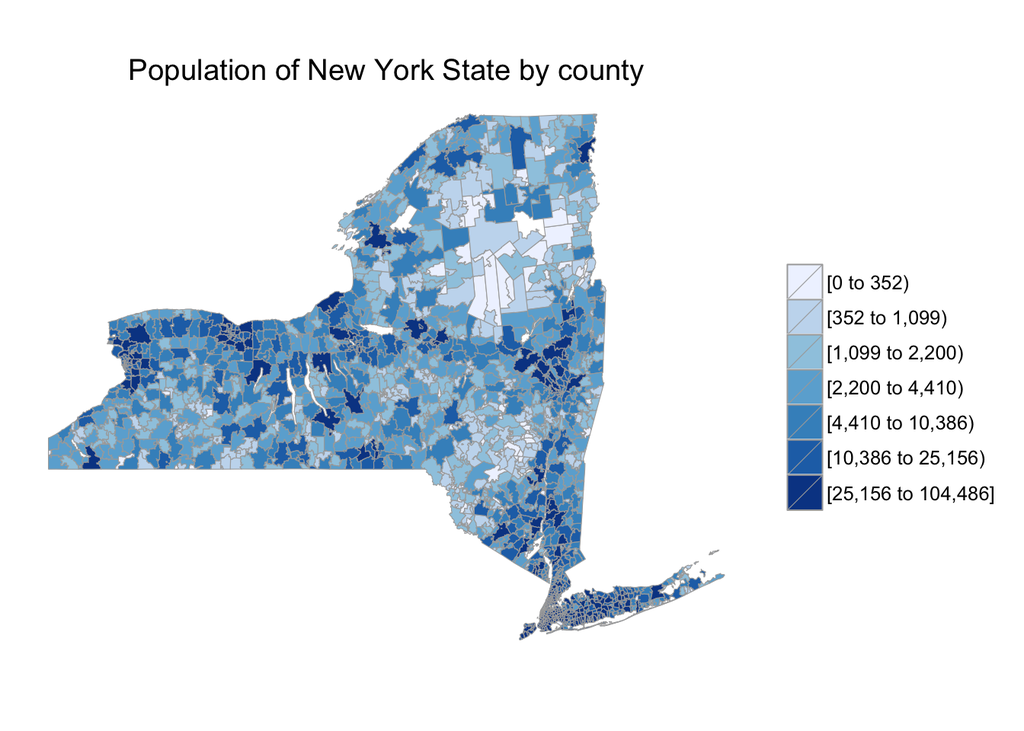

```r
#install.packages("mapproj")
library(mapproj)
library(ggplot2)
data(df_pop_zip)
zip_choropleth(df_pop_zip, state_zoom = "new york", title="Population of New York State by county") + coord_map()
```

Need FIPS code of Manhattan to provide the county to zoom. Google it :)

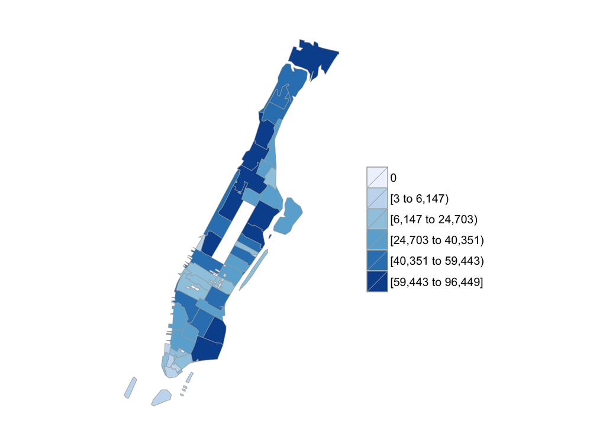

```r
zip_choropleth(df_pop_zip, county_zoom = 36061) + coord_map()
```

Similarly, one can play with demographics at county level and get various insights. A lot of interesting data.

Have fun!